# Graphs in R

# We’re going to cover:

- ggplot()
  - scatter plots
  - line plots
  - boxplots
  - details
    - titles
    - colors
    - facettes
    - multi-figures

We’re going to use the library wooldridge and import the ceo salary dataset. This is a sneakpeak on the datasets that we will be using in eco 585: applied econometrics.

It create a dataframe called ceosal1

```r
library(wooldridge)

data("ceosal1")

names(ceosal1)
```

```
 [1] "salary"   "pcsalary" "sales"    "roe"      "pcroe"    "ros"      "indus"
 [8] "finance"  "consprod" "utility"  "lsalary"  "lsales"
```

We’re going to do some simple examples of graphing with the premiere graphing package in R - ggplot2. This is included in tidyverse, so let’s load that in

```r
library(tidyverse)
```

## Scatterplot

Your traditional scatter plots. You must tell R the data set you are pulling, the x and y axis and then add , that’s right, add (plus sign) that you would like a scatter plot. This is particularly important for continuous variables.

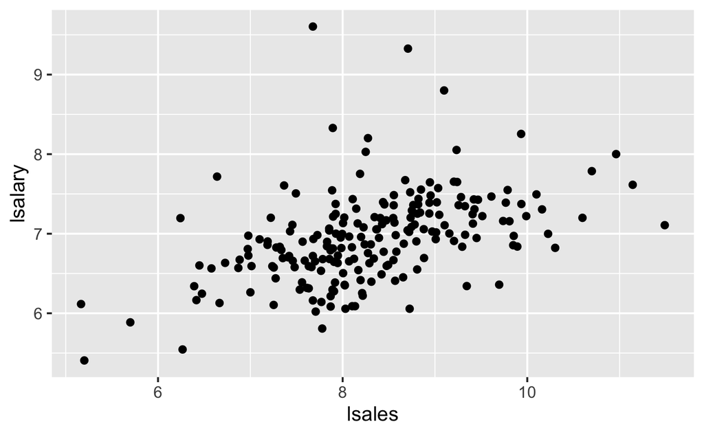

```r
ggplot(data = ceosal1, mapping = aes(x = lsales, y =  lsalary)) + geom_point()
```

What’s kind of nice about this is that you can assign the core information to a variable and then add on what kind of graph you want to see.

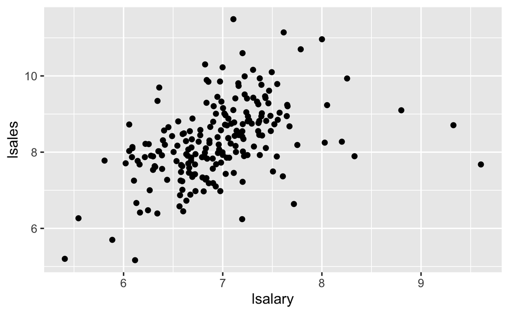

```r
sal_sales <- ggplot(data = ceosal1, mapping = aes(x = lsalary, y =  lsales))

#below is where you see that additional graphing capability
sal_sales + geom_point()
```

# Lineplots

So, creating line graphs are easy. We just change the ending of the type of plot we want.

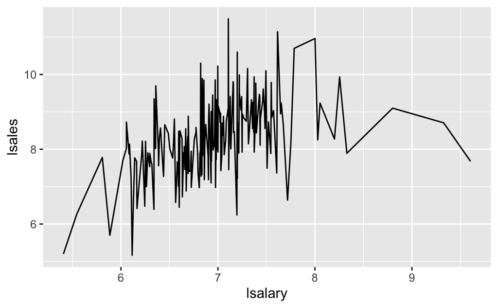

```r
sal_sales + geom_line()
```

## boxplots

box plots are similarly easy to show; Here is a [link to all of the named colors in R](https://sape.inf.usi.ch/quick-reference/ggplot2/colour)

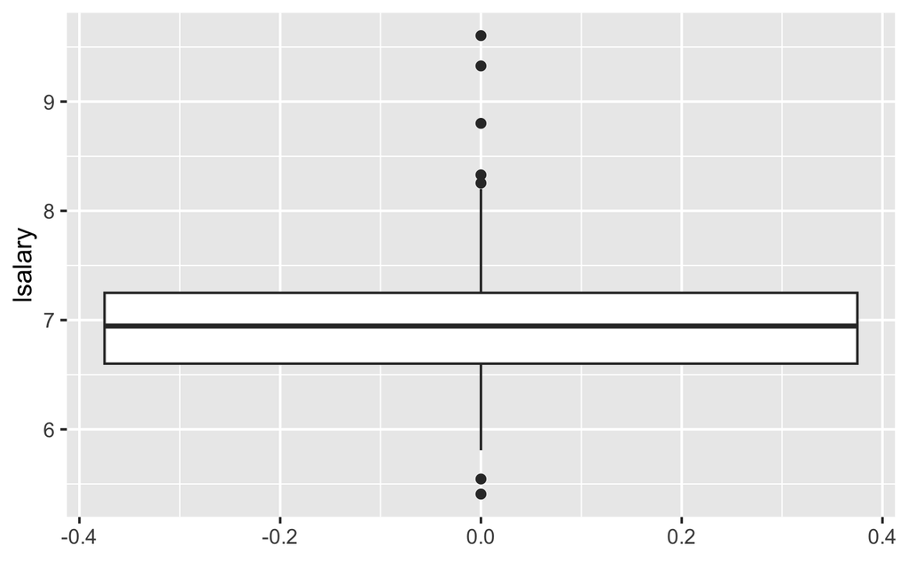

```r
ggplot(data = ceosal1, mapping = aes(y = lsalary))  + geom_boxplot()
```

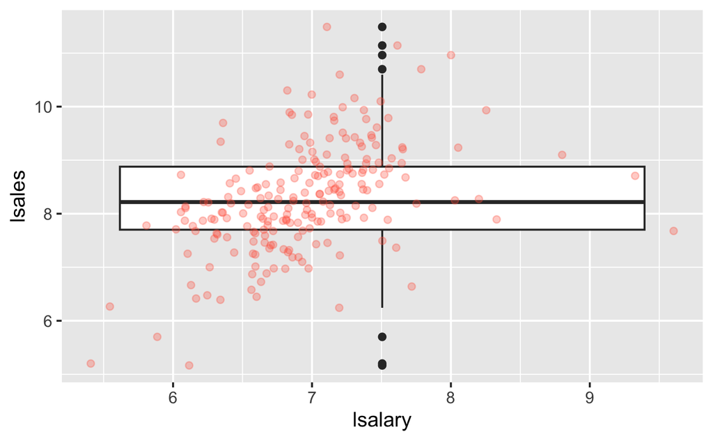

```r
 # we can even add some more detail about the distribution and change the color
sal_sales + geom_boxplot() + geom_jitter(alpha = 0.3, color = "tomato")
```

```r
#creating a category variable that I can get information by groups
ceosal <- pivot_longer(ceosal1, c('indus':'utility'), names_to='cat_industry', values_to= 'roe2')
ceosal<-subset(ceosal,  roe2!=0)
ceosal$roe2<- NULL
```

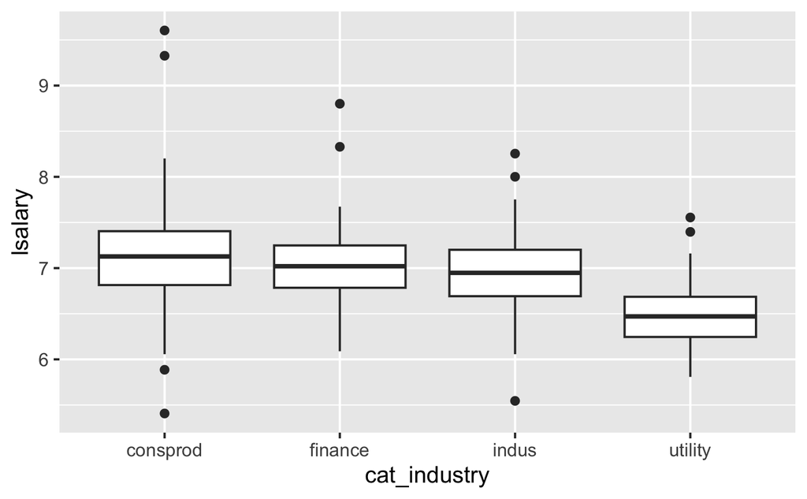

```r
ggplot(data = ceosal, mapping = aes(y = lsalary, x  = cat_industry)) + geom_boxplot()
```

## Faceting

You can create multiple graphs in one figure through faceting.

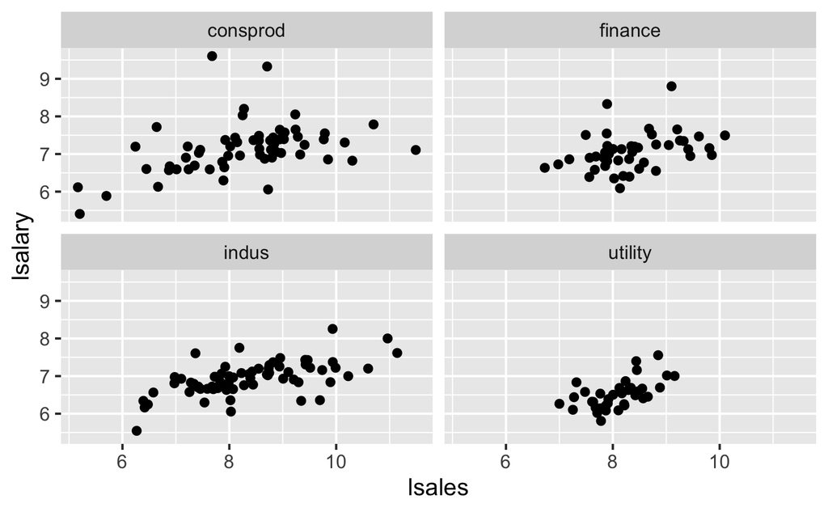

```r
ceo_graph <- ggplot(data = ceosal, mapping = aes(y = lsalary, x  = lsales))

ceo_graph + geom_point()  + facet_wrap(facets = vars(cat_industry))
```

# Customization

We can do a lot of custom details to make our graphs look perfect. You can take a look at different themes[here](https://ggplot2.tidyverse.org/reference/ggtheme.html).

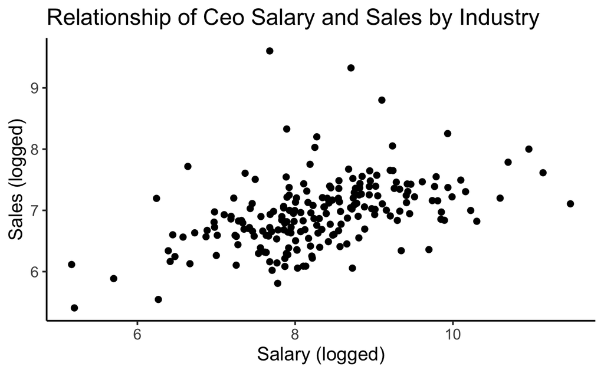

```r
ceo_sal_scatter <- ceo_graph + geom_point() +
labs(title = "Relationship of Ceo Salary and Sales by Industry",
        x = "Salary (logged)",
        y = "Sales (logged)") +
    theme_classic() +  # we can add themes (same as in python)
    theme(text=element_text(size = 12))  #specify text size across the entire graph

ceo_sal_scatter
```

Some good advice on how to write short descriptions about data visualization can be found here: https://medium.com/nightingale/writing-alt-text-for-data-visualization-2a218ef43f81

This is really for thinking about alt text, what we often do for twitter or even markdown - but I think it’s a good way to think about how to title and explain graphs quickly.

## Colors

As always we can add colors. Color is an option in any of the graphs function we use. Lots of palettes, colors and options can be found [here](https://www.datanovia.com/en/blog/top-r-color-palettes-to-know-for-great-data-visualization/)

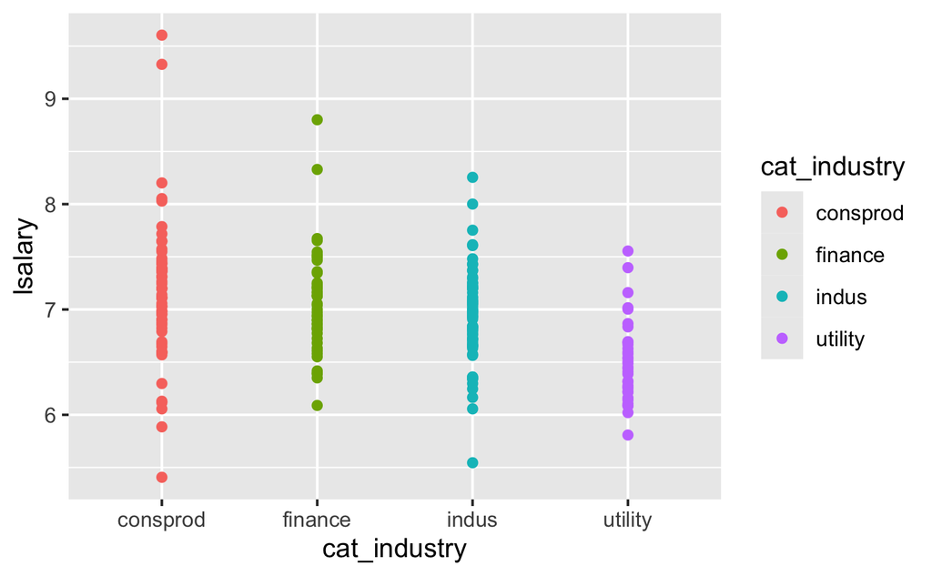

```r
library(RColorBrewer) # This package helps add color palettes

ggplot(data = ceosal, mapping = aes(y = lsalary, x  = cat_industry)) + geom_point(aes(color = cat_industry))
```

We can also add our transparency

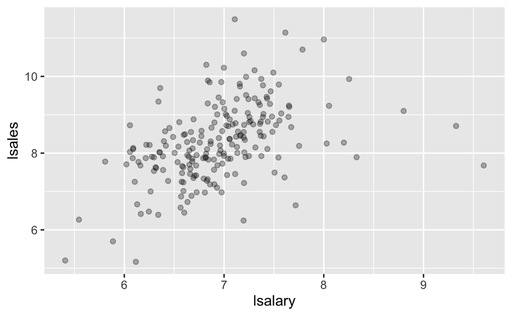

```r
sal_sales + geom_point(alpha = .3)
```

# Multiple Plots

As in python, you can put together plots on one figure

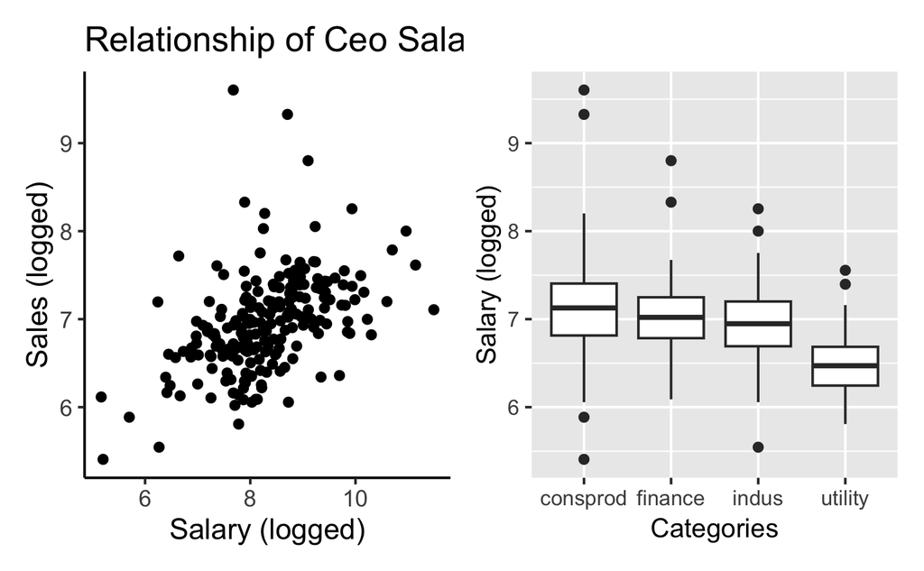

```r
#must import this package to facilitate (don't forget to install it - only have to do it once)
library(patchwork)

boxplots <- ggplot(data = ceosal, mapping = aes(y = lsalary, x  = cat_industry)) + geom_boxplot() +
  labs(y = "Salary (logged)",
        x = "Categories")

ceo_sal_scatter / boxplots  + plot_layout(ncol = 2, nrow=1)  +theme(plot.title = element_text(hjust=-.2))
```

```r
#also ggarrange()
```

# exporting

with the function ggsave, you can export any graph (remember it’s where you set your working directory unless you specify otherwise)

```r
getwd()
```

```
[1] "/Users/mkaltenberg/Documents/GitHub/Data_Analysis_Python_R/Becoming an R Viz Kid"
```

```r
plots_ceo <- ceo_sal_scatter / boxplots + plot_layout(heights = c(2, 2))

ggsave("plotsfromclass.jpeg", plot = plots_ceo, dpi = 300)

#saving at a dpi of 300
# you can also specify the height and width if needed
```